# Risk Factor Analysis

## Outcome Variable

**Outcome Variable:** wasted

## Predictor Variables

**Intervention Variable:** cleanck

**Adjustment Set:**

- arm
- sex
- W_mage
- meducyrs
- feducyrs
- hhwealth_quart
- W_nrooms
- W_nhh
- W_nchldlt5
- trth2o
- impfloor
- delta_meducyrs
- delta_feducyrs
- delta_hhwealth_quart
- delta_W_nrooms
- delta_W_nhh
- delta_W_nchldlt5
- delta_trth2o
- delta_impfloor

## Stratifying Variables

The analysis was stratified on these variable(s):

- agecat
- studyid
- country

## Data Summary

| agecat | studyid | country | cleanck | wasted | n_cell | n |
| --- | --- | --- | --- | --- | --- | --- |
| Birth | CMC-V-BCS-2002 | INDIA | 1 | 0 | 34 | 86 |
| Birth | CMC-V-BCS-2002 | INDIA | 1 | 1 | 3 | 86 |
| Birth | CMC-V-BCS-2002 | INDIA | 0 | 0 | 41 | 86 |
| Birth | CMC-V-BCS-2002 | INDIA | 0 | 1 | 8 | 86 |
| Birth | GMS-Nepal | NEPAL | 1 | 0 | 5 | 570 |
| Birth | GMS-Nepal | NEPAL | 1 | 1 | 4 | 570 |
| Birth | GMS-Nepal | NEPAL | 0 | 0 | 448 | 570 |
| Birth | GMS-Nepal | NEPAL | 0 | 1 | 113 | 570 |
| Birth | IRC | INDIA | 1 | 0 | 157 | 337 |
| Birth | IRC | INDIA | 1 | 1 | 41 | 337 |
| Birth | IRC | INDIA | 0 | 0 | 91 | 337 |
| Birth | IRC | INDIA | 0 | 1 | 48 | 337 |
| Birth | MAL-ED | PERU | 1 | 0 | 1 | 2 |
| Birth | MAL-ED | PERU | 1 | 1 | 0 | 2 |
| Birth | MAL-ED | PERU | 0 | 0 | 1 | 2 |
| Birth | MAL-ED | PERU | 0 | 1 | 0 | 2 |
| Birth | NIH-Crypto | BANGLADESH | 1 | 0 | 275 | 543 |
| Birth | NIH-Crypto | BANGLADESH | 1 | 1 | 61 | 543 |
| Birth | NIH-Crypto | BANGLADESH | 0 | 0 | 146 | 543 |
| Birth | NIH-Crypto | BANGLADESH | 0 | 1 | 61 | 543 |
| Birth | PROVIDE | BANGLADESH | 1 | 0 | 341 | 532 |
| Birth | PROVIDE | BANGLADESH | 1 | 1 | 92 | 532 |
| Birth | PROVIDE | BANGLADESH | 0 | 0 | 74 | 532 |
| Birth | PROVIDE | BANGLADESH | 0 | 1 | 25 | 532 |
| 6 months | CMC-V-BCS-2002 | INDIA | 1 | 0 | 146 | 368 |
| 6 months | CMC-V-BCS-2002 | INDIA | 1 | 1 | 16 | 368 |
| 6 months | CMC-V-BCS-2002 | INDIA | 0 | 0 | 176 | 368 |
| 6 months | CMC-V-BCS-2002 | INDIA | 0 | 1 | 30 | 368 |
| 6 months | GMS-Nepal | NEPAL | 1 | 0 | 8 | 505 |
| 6 months | GMS-Nepal | NEPAL | 1 | 1 | 0 | 505 |
| 6 months | GMS-Nepal | NEPAL | 0 | 0 | 451 | 505 |
| 6 months | GMS-Nepal | NEPAL | 0 | 1 | 46 | 505 |
| 6 months | IRC | INDIA | 1 | 0 | 195 | 398 |
| 6 months | IRC | INDIA | 1 | 1 | 34 | 398 |
| 6 months | IRC | INDIA | 0 | 0 | 150 | 398 |
| 6 months | IRC | INDIA | 0 | 1 | 19 | 398 |
| 6 months | MAL-ED | SOUTH AFRICA | 1 | 0 | 1 | 1 |
| 6 months | MAL-ED | SOUTH AFRICA | 1 | 1 | 0 | 1 |
| 6 months | MAL-ED | SOUTH AFRICA | 0 | 0 | 0 | 1 |
| 6 months | MAL-ED | SOUTH AFRICA | 0 | 1 | 0 | 1 |
| 6 months | NIH-Crypto | BANGLADESH | 1 | 0 | 321 | 545 |
| 6 months | NIH-Crypto | BANGLADESH | 1 | 1 | 8 | 545 |
| 6 months | NIH-Crypto | BANGLADESH | 0 | 0 | 211 | 545 |
| 6 months | NIH-Crypto | BANGLADESH | 0 | 1 | 5 | 545 |
| 6 months | PROVIDE | BANGLADESH | 1 | 0 | 481 | 603 |
| 6 months | PROVIDE | BANGLADESH | 1 | 1 | 16 | 603 |
| 6 months | PROVIDE | BANGLADESH | 0 | 0 | 97 | 603 |
| 6 months | PROVIDE | BANGLADESH | 0 | 1 | 9 | 603 |
| 24 months | CMC-V-BCS-2002 | INDIA | 1 | 0 | 157 | 372 |
| 24 months | CMC-V-BCS-2002 | INDIA | 1 | 1 | 6 | 372 |
| 24 months | CMC-V-BCS-2002 | INDIA | 0 | 0 | 192 | 372 |
| 24 months | CMC-V-BCS-2002 | INDIA | 0 | 1 | 17 | 372 |
| 24 months | GMS-Nepal | NEPAL | 1 | 0 | 4 | 434 |
| 24 months | GMS-Nepal | NEPAL | 1 | 1 | 1 | 434 |
| 24 months | GMS-Nepal | NEPAL | 0 | 0 | 350 | 434 |
| 24 months | GMS-Nepal | NEPAL | 0 | 1 | 79 | 434 |
| 24 months | IRC | INDIA | 1 | 0 | 216 | 400 |
| 24 months | IRC | INDIA | 1 | 1 | 15 | 400 |
| 24 months | IRC | INDIA | 0 | 0 | 153 | 400 |
| 24 months | IRC | INDIA | 0 | 1 | 16 | 400 |
| 24 months | MAL-ED | SOUTH AFRICA | 1 | 0 | 1 | 1 |
| 24 months | MAL-ED | SOUTH AFRICA | 1 | 1 | 0 | 1 |
| 24 months | MAL-ED | SOUTH AFRICA | 0 | 0 | 0 | 1 |
| 24 months | MAL-ED | SOUTH AFRICA | 0 | 1 | 0 | 1 |
| 24 months | NIH-Crypto | BANGLADESH | 1 | 0 | 185 | 410 |
| 24 months | NIH-Crypto | BANGLADESH | 1 | 1 | 14 | 410 |
| 24 months | NIH-Crypto | BANGLADESH | 0 | 0 | 193 | 410 |
| 24 months | NIH-Crypto | BANGLADESH | 0 | 1 | 18 | 410 |
| 24 months | PROVIDE | BANGLADESH | 1 | 0 | 438 | 579 |
| 24 months | PROVIDE | BANGLADESH | 1 | 1 | 42 | 579 |
| 24 months | PROVIDE | BANGLADESH | 0 | 0 | 79 | 579 |
| 24 months | PROVIDE | BANGLADESH | 0 | 1 | 20 | 579 |

The following strata were considered:

- agecat: 24 months, studyid: CMC-V-BCS-2002, country: INDIA
- agecat: 24 months, studyid: GMS-Nepal, country: NEPAL
- agecat: 24 months, studyid: IRC, country: INDIA
- agecat: 24 months, studyid: MAL-ED, country: SOUTH AFRICA
- agecat: 24 months, studyid: NIH-Crypto, country: BANGLADESH
- agecat: 24 months, studyid: PROVIDE, country: BANGLADESH
- agecat: 6 months, studyid: CMC-V-BCS-2002, country: INDIA
- agecat: 6 months, studyid: GMS-Nepal, country: NEPAL
- agecat: 6 months, studyid: IRC, country: INDIA
- agecat: 6 months, studyid: MAL-ED, country: SOUTH AFRICA
- agecat: 6 months, studyid: NIH-Crypto, country: BANGLADESH
- agecat: 6 months, studyid: PROVIDE, country: BANGLADESH
- agecat: Birth, studyid: CMC-V-BCS-2002, country: INDIA
- agecat: Birth, studyid: GMS-Nepal, country: NEPAL
- agecat: Birth, studyid: IRC, country: INDIA
- agecat: Birth, studyid: MAL-ED, country: PERU
- agecat: Birth, studyid: NIH-Crypto, country: BANGLADESH
- agecat: Birth, studyid: PROVIDE, country: BANGLADESH

### Dropped Strata

Some strata were dropped due to rare outcomes:

- agecat: Birth, studyid: CMC-V-BCS-2002, country: INDIA
- agecat: Birth, studyid: GMS-Nepal, country: NEPAL
- agecat: Birth, studyid: MAL-ED, country: PERU
- agecat: 6 months, studyid: GMS-Nepal, country: NEPAL
- agecat: 6 months, studyid: MAL-ED, country: SOUTH AFRICA
- agecat: 24 months, studyid: GMS-Nepal, country: NEPAL
- agecat: 24 months, studyid: MAL-ED, country: SOUTH AFRICA

## Methods Detail

We’re interested in the causal parameters $E[Y_a]$ for all values of $a \in \mathcal{A}$. These parameters represent the mean outcome if, possibly contrary to fact, we intervened to set all units to have $A=a$. Under the randomization and positivity assumptions, these are identified by the statistical parameters $\psi_a=E_W[E_{Y|A,W}(Y|A=a,W)]$. In addition, we’re interested in the mean of $Y$, $E[Y]$ under no intervention (the observed mean). We will estimate these parameters by using SuperLearner to fit the relevant likelihood factors – $E_{Y|A,W}(Y|A=a,W)$ and $p(A=a|W)$, and then updating our likelihood fit using a joint TMLE.

For unadjusted analyses ($W=\{\}$), initial likelihoods were estimated using Lrnr_glm to estimate the simple $E(Y|A)$ and Lrnr_mean to estimate $p(A)$. For adjusted analyses, a small library containing Lrnr_glmnet, Lrnr_xgboost, and Lrnr_mean was used.

Having estimated these parameters, we will then use the delta method to estimate relative risks and attributable risks relative to a prespecified baseline level of $A$.

# Results Detail

## Results Plots

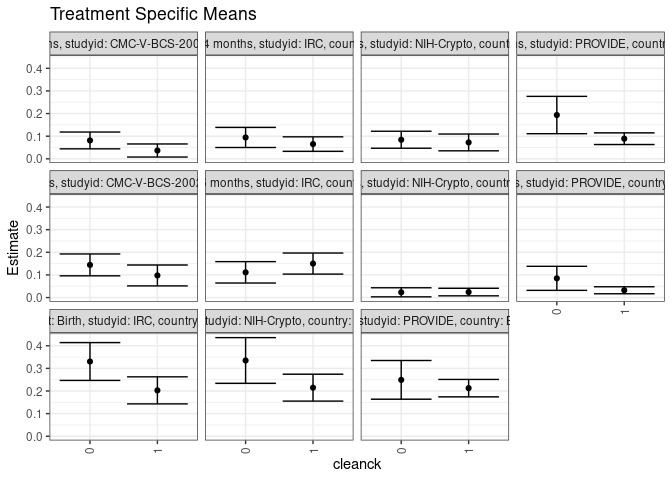

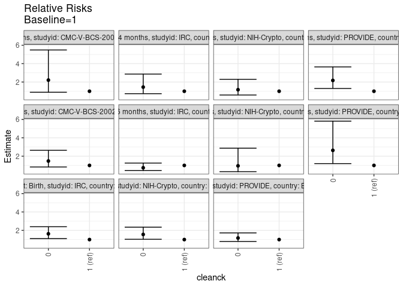

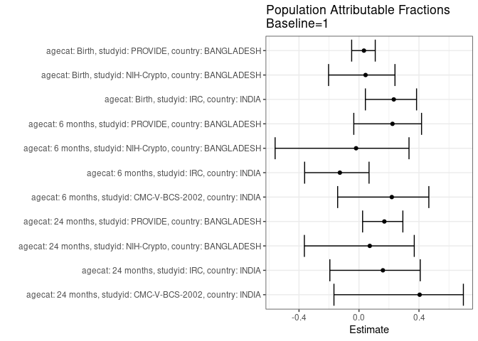

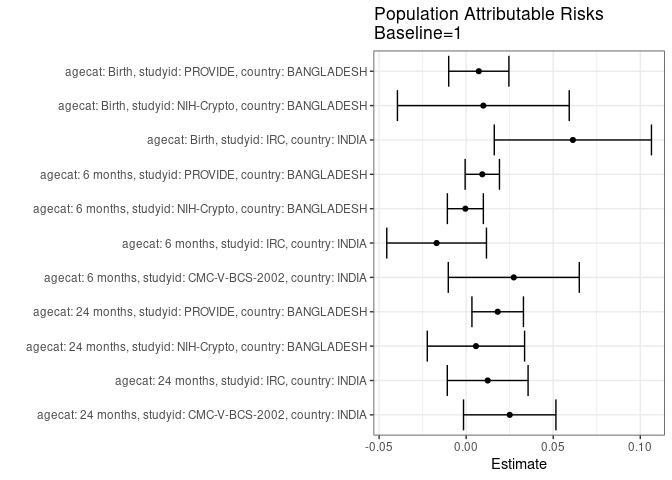

## Results Table

### Parameter: TSM

| agecat | studyid | country | intervention_level | baseline_level | estimate | ci_lower | ci_upper |
| --- | --- | --- | --- | --- | --- | --- | --- |
| Birth | IRC | INDIA | 1 | NA | 0.2028066 | 0.1430160 | 0.2625972 |
| Birth | IRC | INDIA | 0 | NA | 0.3302896 | 0.2467094 | 0.4138699 |
| Birth | NIH-Crypto | BANGLADESH | 1 | NA | 0.2148137 | 0.1553181 | 0.2743094 |
| Birth | NIH-Crypto | BANGLADESH | 0 | NA | 0.3348683 | 0.2338924 | 0.4358443 |
| Birth | PROVIDE | BANGLADESH | 1 | NA | 0.2126651 | 0.1740910 | 0.2512392 |
| Birth | PROVIDE | BANGLADESH | 0 | NA | 0.2492917 | 0.1637653 | 0.3348180 |
| 6 months | CMC-V-BCS-2002 | INDIA | 1 | NA | 0.0976453 | 0.0514385 | 0.1438521 |
| 6 months | CMC-V-BCS-2002 | INDIA | 0 | NA | 0.1442671 | 0.0958552 | 0.1926791 |
| 6 months | IRC | INDIA | 1 | NA | 0.1501367 | 0.1035952 | 0.1966781 |
| 6 months | IRC | INDIA | 0 | NA | 0.1114029 | 0.0641105 | 0.1586953 |
| 6 months | NIH-Crypto | BANGLADESH | 1 | NA | 0.0243161 | 0.0076570 | 0.0409752 |
| 6 months | NIH-Crypto | BANGLADESH | 0 | NA | 0.0231481 | 0.0030761 | 0.0432202 |
| 6 months | PROVIDE | BANGLADESH | 1 | NA | 0.0321932 | 0.0166619 | 0.0477244 |
| 6 months | PROVIDE | BANGLADESH | 0 | NA | 0.0849057 | 0.0317980 | 0.1380133 |
| 24 months | CMC-V-BCS-2002 | INDIA | 1 | NA | 0.0368098 | 0.0078646 | 0.0657550 |
| 24 months | CMC-V-BCS-2002 | INDIA | 0 | NA | 0.0813397 | 0.0442299 | 0.1184495 |
| 24 months | IRC | INDIA | 1 | NA | 0.0651406 | 0.0331358 | 0.0971455 |
| 24 months | IRC | INDIA | 0 | NA | 0.0944284 | 0.0499754 | 0.1388814 |
| 24 months | NIH-Crypto | BANGLADESH | 1 | NA | 0.0724364 | 0.0353340 | 0.1095388 |
| 24 months | NIH-Crypto | BANGLADESH | 0 | NA | 0.0843722 | 0.0468196 | 0.1219248 |
| 24 months | PROVIDE | BANGLADESH | 1 | NA | 0.0889741 | 0.0632038 | 0.1147443 |
| 24 months | PROVIDE | BANGLADESH | 0 | NA | 0.1935909 | 0.1111085 | 0.2760732 |

### Parameter: E(Y)

| agecat | studyid | country | intervention_level | baseline_level | estimate | ci_lower | ci_upper |
| --- | --- | --- | --- | --- | --- | --- | --- |
| Birth | IRC | INDIA | NA | NA | 0.2640950 | 0.2169571 | 0.3112328 |
| Birth | NIH-Crypto | BANGLADESH | NA | NA | 0.2246777 | 0.1895403 | 0.2598151 |
| Birth | PROVIDE | BANGLADESH | NA | NA | 0.2199248 | 0.1846953 | 0.2551543 |
| 6 months | CMC-V-BCS-2002 | INDIA | NA | NA | 0.1250000 | 0.0911644 | 0.1588356 |
| 6 months | IRC | INDIA | NA | NA | 0.1331658 | 0.0997450 | 0.1665867 |
| 6 months | NIH-Crypto | BANGLADESH | NA | NA | 0.0238532 | 0.0110305 | 0.0366759 |
| 6 months | PROVIDE | BANGLADESH | NA | NA | 0.0414594 | 0.0255348 | 0.0573839 |
| 24 months | CMC-V-BCS-2002 | INDIA | NA | NA | 0.0618280 | 0.0373207 | 0.0863352 |
| 24 months | IRC | INDIA | NA | NA | 0.0775000 | 0.0512641 | 0.1037359 |
| 24 months | NIH-Crypto | BANGLADESH | NA | NA | 0.0780488 | 0.0520518 | 0.1040458 |
| 24 months | PROVIDE | BANGLADESH | NA | NA | 0.1070812 | 0.0818727 | 0.1322897 |

### Parameter: RR

| agecat | studyid | country | intervention_level | baseline_level | estimate | ci_lower | ci_upper |
| --- | --- | --- | --- | --- | --- | --- | --- |
| Birth | IRC | INDIA | 1 | 1 | 1.0000000 | 1.0000000 | 1.000000 |
| Birth | IRC | INDIA | 0 | 1 | 1.6285943 | 1.1054715 | 2.399265 |
| Birth | NIH-Crypto | BANGLADESH | 1 | 1 | 1.0000000 | 1.0000000 | 1.000000 |
| Birth | NIH-Crypto | BANGLADESH | 0 | 1 | 1.5588778 | 1.0345103 | 2.349034 |
| Birth | PROVIDE | BANGLADESH | 1 | 1 | 1.0000000 | 1.0000000 | 1.000000 |
| Birth | PROVIDE | BANGLADESH | 0 | 1 | 1.1722265 | 0.7962030 | 1.725835 |
| 6 months | CMC-V-BCS-2002 | INDIA | 1 | 1 | 1.0000000 | 1.0000000 | 1.000000 |
| 6 months | CMC-V-BCS-2002 | INDIA | 0 | 1 | 1.4774604 | 0.8263831 | 2.641498 |
| 6 months | IRC | INDIA | 1 | 1 | 1.0000000 | 1.0000000 | 1.000000 |
| 6 months | IRC | INDIA | 0 | 1 | 0.7420099 | 0.4384996 | 1.255597 |
| 6 months | NIH-Crypto | BANGLADESH | 1 | 1 | 1.0000000 | 1.0000000 | 1.000000 |
| 6 months | NIH-Crypto | BANGLADESH | 0 | 1 | 0.9519676 | 0.3152693 | 2.874502 |
| 6 months | PROVIDE | BANGLADESH | 1 | 1 | 1.0000000 | 1.0000000 | 1.000000 |
| 6 months | PROVIDE | BANGLADESH | 0 | 1 | 2.6373821 | 1.1970491 | 5.810776 |
| 24 months | CMC-V-BCS-2002 | INDIA | 1 | 1 | 1.0000000 | 1.0000000 | 1.000000 |
| 24 months | CMC-V-BCS-2002 | INDIA | 0 | 1 | 2.2097289 | 0.8902591 | 5.484809 |
| 24 months | IRC | INDIA | 1 | 1 | 1.0000000 | 1.0000000 | 1.000000 |
| 24 months | IRC | INDIA | 0 | 1 | 1.4496088 | 0.7336207 | 2.864376 |
| 24 months | NIH-Crypto | BANGLADESH | 1 | 1 | 1.0000000 | 1.0000000 | 1.000000 |
| 24 months | NIH-Crypto | BANGLADESH | 0 | 1 | 1.1647763 | 0.5909003 | 2.295995 |
| 24 months | PROVIDE | BANGLADESH | 1 | 1 | 1.0000000 | 1.0000000 | 1.000000 |
| 24 months | PROVIDE | BANGLADESH | 0 | 1 | 2.1758124 | 1.2997226 | 3.642439 |

### Parameter: PAR

| agecat | studyid | country | intervention_level | baseline_level | estimate | ci_lower | ci_upper |
| --- | --- | --- | --- | --- | --- | --- | --- |
| Birth | IRC | INDIA | 1 | NA | 0.0612884 | 0.0161496 | 0.1064271 |
| Birth | NIH-Crypto | BANGLADESH | 1 | NA | 0.0098640 | -0.0394731 | 0.0592011 |
| Birth | PROVIDE | BANGLADESH | 1 | NA | 0.0072597 | -0.0100301 | 0.0245495 |
| 6 months | CMC-V-BCS-2002 | INDIA | 1 | NA | 0.0273547 | -0.0102657 | 0.0649750 |
| 6 months | IRC | INDIA | 1 | NA | -0.0169708 | -0.0455992 | 0.0116575 |
| 6 months | NIH-Crypto | BANGLADESH | 1 | NA | -0.0004629 | -0.0108012 | 0.0098754 |
| 6 months | PROVIDE | BANGLADESH | 1 | NA | 0.0092662 | -0.0005917 | 0.0191241 |
| 24 months | CMC-V-BCS-2002 | INDIA | 1 | NA | 0.0250181 | -0.0015188 | 0.0515551 |
| 24 months | IRC | INDIA | 1 | NA | 0.0123594 | -0.0108407 | 0.0355595 |
| 24 months | NIH-Crypto | BANGLADESH | 1 | NA | 0.0056124 | -0.0223337 | 0.0335585 |
| 24 months | PROVIDE | BANGLADESH | 1 | NA | 0.0181071 | 0.0033145 | 0.0328997 |

### Parameter: PAF

| agecat | studyid | country | intervention_level | baseline_level | estimate | ci_lower | ci_upper |
| --- | --- | --- | --- | --- | --- | --- | --- |
| Birth | IRC | INDIA | 1 | NA | 0.2320694 | 0.0426985 | 0.3839795 |
| Birth | NIH-Crypto | BANGLADESH | 1 | NA | 0.0439028 | -0.2027649 | 0.2399830 |
| Birth | PROVIDE | BANGLADESH | 1 | NA | 0.0330100 | -0.0488387 | 0.1084714 |
| 6 months | CMC-V-BCS-2002 | INDIA | 1 | NA | 0.2188374 | -0.1423290 | 0.4658149 |
| 6 months | IRC | INDIA | 1 | NA | -0.1274414 | -0.3625192 | 0.0670780 |
| 6 months | NIH-Crypto | BANGLADESH | 1 | NA | -0.0194061 | -0.5593435 | 0.3335728 |
| 6 months | PROVIDE | BANGLADESH | 1 | NA | 0.2235010 | -0.0346153 | 0.4172223 |
| 24 months | CMC-V-BCS-2002 | INDIA | 1 | NA | 0.4046412 | -0.1668932 | 0.6962429 |
| 24 months | IRC | INDIA | 1 | NA | 0.1594760 | -0.1942406 | 0.4084269 |
| 24 months | NIH-Crypto | BANGLADESH | 1 | NA | 0.0719089 | -0.3642636 | 0.3686315 |
| 24 months | PROVIDE | BANGLADESH | 1 | NA | 0.1690970 | 0.0240916 | 0.2925568 |